# Lab 22: Machine Learning

BioX R Bootcamp

2020-08-17

# Goal

In this lab we will learn the basics of Machine Learning (ML). We will focus on supervised learning.

# Setup Git and GitHub (Optional)

Before delving into the Machine Learning applications, we will first quickly learn how to use git and GitHub as a way to keep track of your code. This will hopefully be useful for you in your future data analysis projects!

1. Sign up for an account: https://github.com/
2. Install GitHub client: https://desktop.github.com/
3. (Optional) Request student discount: https://education.github.com/pack
4. Create new private repository:
   - Go to: https://github.com/YourUserName
   - Select `Repositories` tab
   - Click `New` button
   - Select `Public` (or `Private`) and `Initialize this repository with a README`
   - Edit `README.md`
   - Write and save `README.md`:

   ```
   # Hello World

   This is my first git repository.
   ```

5. Clone your repository
   - Click `Clone or download` green button, then `Open in Desktop`
   - Click `Clone` button to make a local copy of your repository
6. Move today’s `Rmd` file in cloned folder
7. Synchronize your local copy with the one on GitHub
   - Click `1 Uncommitted Change`
   - Write in summary text field:

   ```
   This is my first commit
   ```

   - Click `Commit and Sync master`
8. Continue with the labs, when you are done `Commit and Sync master` to save everything you have done on GitHub

Now let us move on to to the main part of this lab:

# Packages

Install packages.

```r
pkgs_needed = c("MASS","ExperimentHub", "tidyverse","glmnet",
                "RColorBrewer","caret", "magrittr")
letsinstall = setdiff(pkgs_needed, installed.packages())
if (length(letsinstall) > 0) {
  BiocManager::install(setdiff(pkgs_needed, installed.packages()))
}
```

```
##
##  /var/folders/n4/xn85jz2x0yxd_4g4d48d6tth0000gn/T//RtmpbJfJDR/downloaded_packages
```

Load packages.

```r
library("tidyverse")
library("MASS")
library("ExperimentHub")
library("glmnet")
library("RColorBrewer")
library("caret")
library("magrittr")
```

# Linear discrimination

We start with one of the simplest possible discrimination problems. Our aim is to partition the 2D plane into classes, using class boundaries that are straight lines.

## Diabetes data set

The `diabetes` dataset presents three different groups of diabetes patients and five clinical variables measured on them.

```r
diabetes = read_csv(url("http://web.stanford.edu/class/bios221/data/diabetes.csv"),
                    col_names = TRUE)
diabetes
```

```
## # A tibble: 144 x 7
##       id relwt glufast glutest steady insulin group
##    <dbl> <dbl>   <dbl>   <dbl>  <dbl>   <dbl> <dbl>
##  1     1  0.81      80     356    124      55     3
##  2     3  0.94     105     319    143     105     3
##  3     5  1         90     323    240     143     3
##  4     7  0.91     100     350    221     119     3
##  5     9  0.99      97     379    142      98     3
##  6    11  0.9       91     353    221      53     3
##  7    13  0.96      78     290    136     142     3
##  8    15  0.74      86     312    208      68     3
##  9    17  1.1       90     364    152      76     3
## 10    19  0.83      85     296    116      60     3
## # … with 134 more rows
```

```r
diabetes$group %<>% factor
```

We used the forward-backward pipe operator `%<>%` to convert the `group` column into a factor.

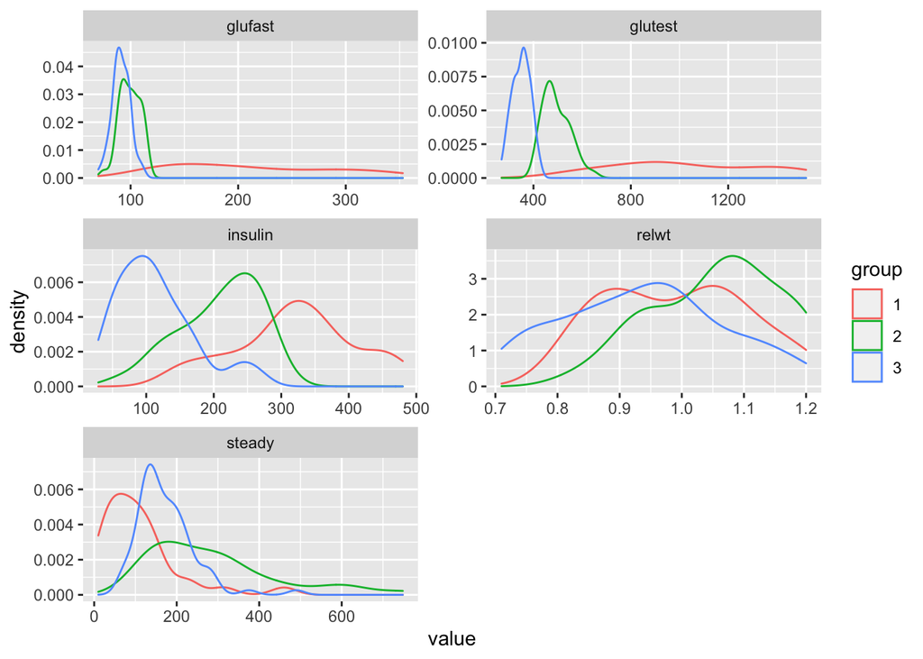

```r
diabetes.long = gather(diabetes, variable, value, -c(id,group))
ggplot(diabetes.long, aes(x = value, col = group)) +
  geom_density() + facet_wrap( ~ variable, ncol = 2, scales = "free")
```

We see already from the one-dimensional distributions that some of the individual variables could potentially predict which group a patient is more likely to belong to. Our goal will be to combine variables to improve these one dimensional predictions.

## LDA

Let’s see whether we can predict the `group` from the `insulin` and `glutest` variables in the diabetes data. It’s always a good idea to first visualize the data:

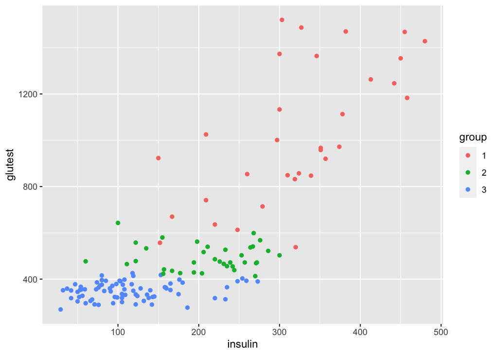

```r
ggdb = ggplot(mapping = aes(x = insulin, y = glutest)) +
         geom_point(aes(colour = group), data = diabetes)
ggdb
```

We’ll start with a method called linear discriminant analysis (LDA). This method is a foundation stone of classification, many of the more complicated (and sometimes more powerful) algorithms are really just generalizations of LDA.

```r
diabetes_lda = lda(group ~ insulin + glutest, data = diabetes) # from MASS package
diabetes_lda
```

```
## Call:
## lda(group ~ insulin + glutest, data = diabetes)
##
## Prior probabilities of groups:
##         1         2         3
## 0.2222222 0.2500000 0.5277778
##
## Group means:
##    insulin   glutest
## 1 320.9375 1027.3750
## 2 208.9722  493.9444
## 3 114.0000  349.9737
##
## Coefficients of linear discriminants:
##                  LD1         LD2
## insulin -0.004463900 -0.01591192
## glutest -0.005784238  0.00480830
##
## Proportion of trace:
##    LD1    LD2
## 0.9677 0.0323
```

```r
ghat = predict(diabetes_lda)$class
table(predicted = ghat, truth = diabetes$group)
```

```
##          truth
## predicted  1  2  3
##         1 25  0  0
##         2  6 24  6
##         3  1 12 70
```

```r
mean(ghat != diabetes$group)
```

```
## [1] 0.1736111
```

Now, let’s visualize the LDA result. We are going to plot the prediction regions for each of the three groups. We do this by creating a grid of points and using our prediction rule on each of them. We’ll then also dig a bit deeper into the mechanics of LDA and plot the class centers. Assembling this visualization requires us to write a bit of code.

```r
make1Dgrid = function(x) {
  rg = grDevices::extendrange(x)
  seq(from = rg[1], to = rg[2], length.out = 100)
}
```

Set up the points for prediction, a $100 \times 100$ grid that covers the data range.

```r
diabetes_grid = with(diabetes,
  expand.grid(insulin = make1Dgrid(insulin),
              glutest = make1Dgrid(glutest)))
```

Do the predictions.

```r
diabetes_grid$ghat = predict(diabetes_lda, newdata = diabetes_grid)$class
```

The group centers.

```r
centers = diabetes_lda$means
```

Now we are ready to plot:

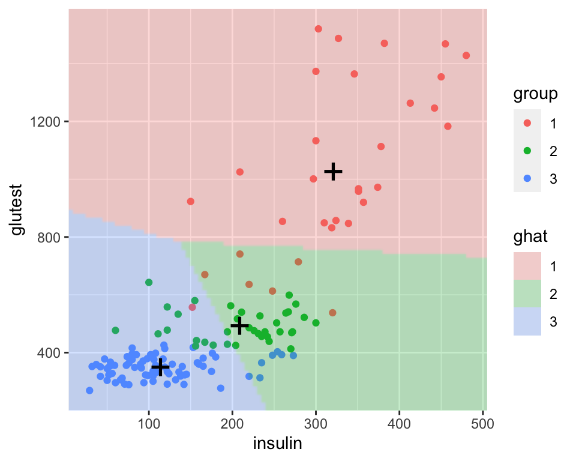

```r
ggdb + geom_raster(
  data = diabetes_grid, alpha = 0.25,
  aes(fill = ghat),
  interpolate = TRUE ) +
  geom_point(data = as_tibble(centers), pch = "+", size = 8) +
  scale_x_continuous(expand = c(0, 0)) +
  scale_y_continuous(expand = c(0, 0))
```

Instead of trying to predict with 2 variables, we could use LDA with all 5 variables.

```r
diabetes_lda5 = lda(group ~ relwt + glufast + glutest +
           steady + insulin, data = diabetes)
diabetes_lda5
```

```
## Call:
## lda(group ~ relwt + glufast + glutest + steady + insulin, data = diabetes)
##
## Prior probabilities of groups:
##         1         2         3
## 0.2222222 0.2500000 0.5277778
##
## Group means:
##       relwt   glufast   glutest   steady  insulin
## 1 0.9915625 213.65625 1027.3750 108.8438 320.9375
## 2 1.0558333  99.30556  493.9444 288.0000 208.9722
## 3 0.9372368  91.18421  349.9737 172.6447 114.0000
##
## Coefficients of linear discriminants:
##                   LD1           LD2
## relwt   -1.339546e+00 -3.7950612048
## glufast  3.301944e-02  0.0373202882
## glutest -1.263978e-02 -0.0068947755
## steady   1.240248e-05 -0.0059924778
## insulin -3.895587e-03  0.0005754322
##
## Proportion of trace:
##    LD1    LD2
## 0.8784 0.1216
```

Let us get the predictions:

```r
ghat5 = predict(diabetes_lda5)$class
table(ghat5, diabetes$group)
```

```
##
## ghat5  1  2  3
##     1 26  0  0
##     2  5 31  3
##     3  1  5 73
```

And the prediction error:

```r
mean(ghat5 != diabetes$group)
```

```
## [1] 0.09722222
```

# Cross-validation

Often machine learning algorithms have parameters that we need to choose. One way of doing this is via cross-validation. Below we will look at one way of achieving this, called leave-one-out cross-validation (LOOCV). For each data point, we fit the whole model without this data point and then we predict its label. The nice thing is that we know the true label of that data point and the learning algorithm did not, hence we can get a reasonable estimate of the algorithm’s performance on “fresh” data (e.g. the misclassification rate or some other metric). Let’s write a function which does this:

```r
estimate_mcl_loocv = function(x, resp) {
  vapply(seq_len(nrow(x)), function(i) {
    fit  = lda(x[-i, ], resp[-i])
    ptrn = predict(fit, newdata = x[-i,, drop = FALSE])$class
    ptst = predict(fit, newdata = x[ i,, drop = FALSE])$class
    c(train = mean(ptrn != resp[-i]), test = (ptst != resp[i]))
  }, FUN.VALUE = numeric(2)) %>% rowMeans %>% t %>% as_tibble
}
```

Now let’s try a simulation:

We generate artificial “apple” and “orange” data and measure $p$ predictors on them. The predictors are constructed in such a way that the first 6 are informative (i.e. apples and oranges are different with respect to these), but the rest are just random noise. We want to try different models where we include the first $k$ predictors. We will use LOOCV to find $k$. Note that from the simulation setting we know we should pick $k=6$ but LOOCV does not know this:

(Remark: The code below might take a while to run – indeed one of the disadvantages of LOOCV is its long run time. If it takes too long you can try reducing the replications from 100 to a small number. In fact, it might be interesting to reduce the replications to 1 since with real datasets you don’t have the luxury of repeating the data generation!)

```r
n = 20
p = 2:20
# This will take a while
mcl = replicate(100, {
  xmat = matrix(rnorm(n * last(p)), nrow = n)
  resp = sample(c("apple", "orange"), n, replace = TRUE)
  xmat[, 1:6] = xmat[, 1:6] + as.integer(factor(resp))

  lapply(p, function(k) {
    estimate_mcl_loocv(xmat[, 1:k], resp)
  }) %>% bind_rows %>% cbind(p = p) %>% gather(variable, value, -p)
}, simplify = FALSE) %>% bind_rows

mcl =  group_by(mcl, p, variable) %>%
   summarise(value = mean(value))
```

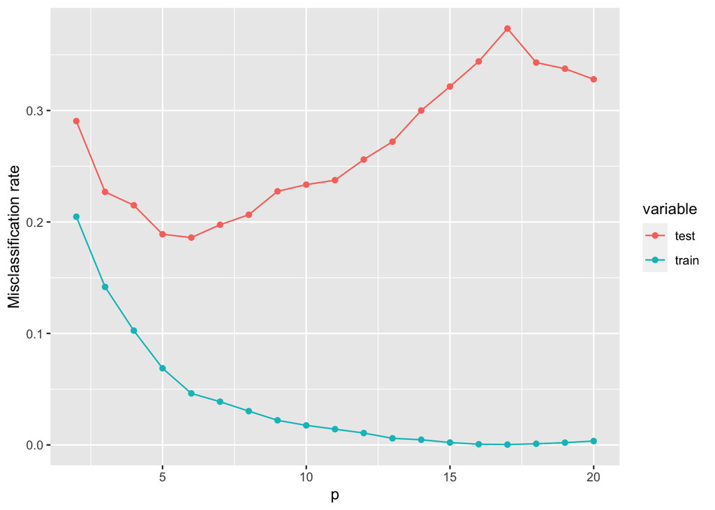

```r
ggplot(mcl, aes(x = p, y = value, col = variable)) + geom_line() +
      geom_point() + ylab("Misclassification rate")
```

In the section below you will see CV used to pick a parameter for LASSO-logistic regression.

# Variance-bias trade-off

```r
library("ExperimentHub")
eh = ExperimentHub()
```

```
## using temporary cache /var/folders/n4/xn85jz2x0yxd_4g4d48d6tth0000gn/T//Rtmpw2HNBi/BiocFileCache
```

```
## snapshotDate(): 2020-04-27
```

```r
zeller = eh[["EH361"]]
```

```
## Bioconductor version 3.11 (BiocManager 1.30.10), R 4.0.2 (2020-06-22)
```

[output not shown]

[output not shown]

[output not shown]

```
## see ?curatedMetagenomicData and browseVignettes('curatedMetagenomicData') for documentation
```

```
## downloading 1 resources
```

```
## retrieving 1 resource
```

```
## loading from cache
```

```r
table(zeller$disease)
```

```
##
##        cancer large_adenoma             n small_adenoma
##            53            15            61            27
```

Explore the `eh` object to see what other datasets there are.

For the following, let’s focus on the normal and cancer samples and set the adenomas aside.

```r
zellerNC = zeller[, zeller$disease %in% c("n", "cancer")]
```

Before jumping into model fitting, as always it’s a good idea to do some exploration of the data. First, let’s look at the sample annotations. The following code prints the data from three randomly picked samples. (Only looking at the first ones, say with the R function `head`, is also an option, but may not be representative of the whole dataset).

```r
pData(zellerNC)[ sample(ncol(zellerNC), 3), ]
```

```
##                     subjectID age gender bmi country disease tnm_stage
## CCIS02379307ST-4-0     FR-828  67   male  28  france  cancer    t1n0m0
## CCIS22958137ST-20-0    FR-506  60   male  26  france  cancer    t4n1m1
## CCIS91228662ST-4-0     FR-275  63   male  31  france  cancer    t1n0m0
##                     ajcc_stage localization     fobt
## CCIS02379307ST-4-0           i           rc positive
## CCIS22958137ST-20-0         iv           rc positive
## CCIS91228662ST-4-0           i           lc negative
##                     wif-1_gene_methylation_test group bodysite ethnicity
## CCIS02379307ST-4-0                     positive   crc    stool     white
## CCIS22958137ST-20-0                    negative   crc    stool     white
## CCIS91228662ST-4-0                     positive   crc    stool     white
##                     number_reads
## CCIS02379307ST-4-0      10574044
## CCIS22958137ST-20-0     98059549
## CCIS91228662ST-4-0      94076829
```

Next, let’s explore the feature names.

```r
rownames(zellerNC)[1:4]
```

```
## [1] "k__Bacteria"                  "k__Viruses"
## [3] "k__Bacteria|p__Firmicutes"    "k__Bacteria|p__Bacteroidetes"
```

```r
rownames(zellerNC)[nrow(zellerNC) + (-2:0)]
```

```
## [1] "k__Bacteria|p__Proteobacteria|c__Deltaproteobacteria|o__Desulfovibrionales|f__Desulfovibrionaceae|g__Desulfovibrio|s__Desulfovibrio_termitidis"
## [2] "k__Viruses|p__Viruses_noname|c__Viruses_noname|o__Viruses_noname|f__Baculoviridae|g__Alphabaculovirus|s__Bombyx_mori_nucleopolyhedrovirus|t__Bombyx_mori_nucleopolyhedrovirus_unclassified"
## [3] "k__Bacteria|p__Proteobacteria|c__Deltaproteobacteria|o__Desulfovibrionales|f__Desulfovibrionaceae|g__Desulfovibrio|s__Desulfovibrio_termitidis|t__GCF_000504305"
```

As you can see, the features are a mixture of abundance quantifications at different taxonomic levels, from **k**ingdom over **p**hylum to **s**pecies. We could select only some of these, but here we continue with all of them. Next, let’s look at the distribution of some of the features. Here, we show an arbitrary choice of two, number 510 and 527; in practice, it is helpful to scroll through many such plots quickly to get an impression.

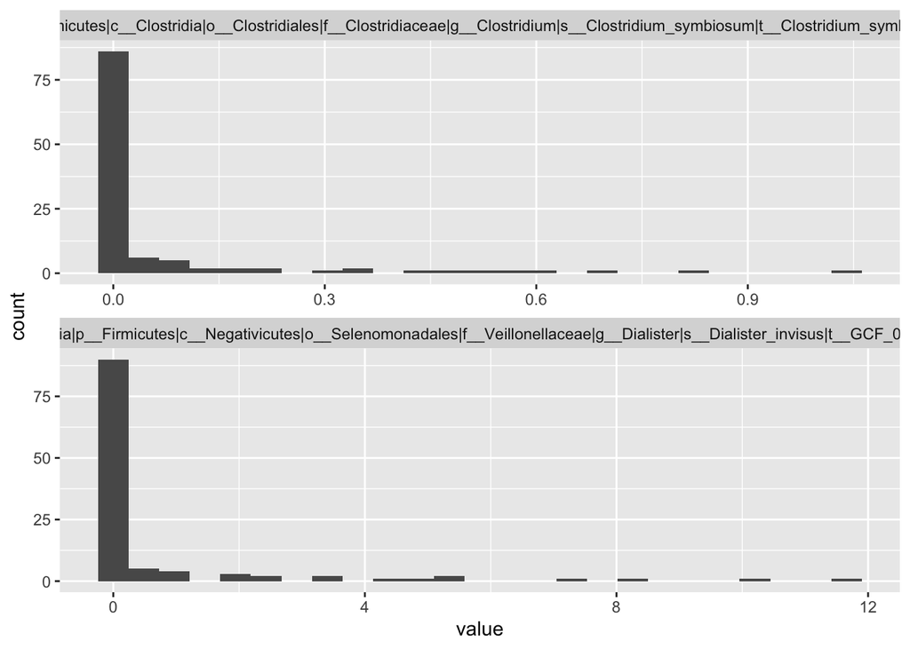

```r
tidy_zeller_subset <- as.data.frame(t(exprs(zellerNC)[c(510, 527), ])) %>%
               mutate(Var2 = colnames(exprs(zellerNC))) %>%
               gather(Var1, value, - Var2)

ggplot(tidy_zeller_subset, aes(x = value)) +
    geom_histogram(bins = 25) +
    facet_wrap( ~ Var1, ncol = 1, scales = "free")
```

In the simplest case, we fit model

$$\log \frac{P(Y=i\,|\,X=x)}{P(Y=k\,|\,X=x)} = \beta^0_i + \beta_i x$$

as follows.

```r
library("glmnet")
glmfit = glmnet(x = t(exprs(zellerNC)),
                y = factor(zellerNC$disease),
                family = "binomial")
```

A remarkable feature of the `glmnet` function is that it fits the model not only for one choice of $\lambda$, but for all possible $\lambda$s at once. For now, let’s look at the prediction performance for, say, $\lambda=0.04$. The name of the function parameter is `s`:

```r
pred = predict(glmfit, newx = t(exprs(zellerNC)), type = "class", s = 0.04)
confusion_table = table(predicted = pred, truth = zellerNC$disease)
confusion_table
```

```
##          truth
## predicted cancer  n
##    cancer     51  0
##    n           2 61
```

**Quiz questions 1 and 2**: What is the true positive rate (TPR) and true negative rate (SPC)? Hint: See book or [Wikipedia](https://en.wikipedia.org/wiki/Sensitivity_and_specificity).

Not bad. But remember that this is on the training data, without cross-validation. Let’s have a closer look at `glmfit`. The `glmnet` package offers a a diagnostic plot that is worth looking at:

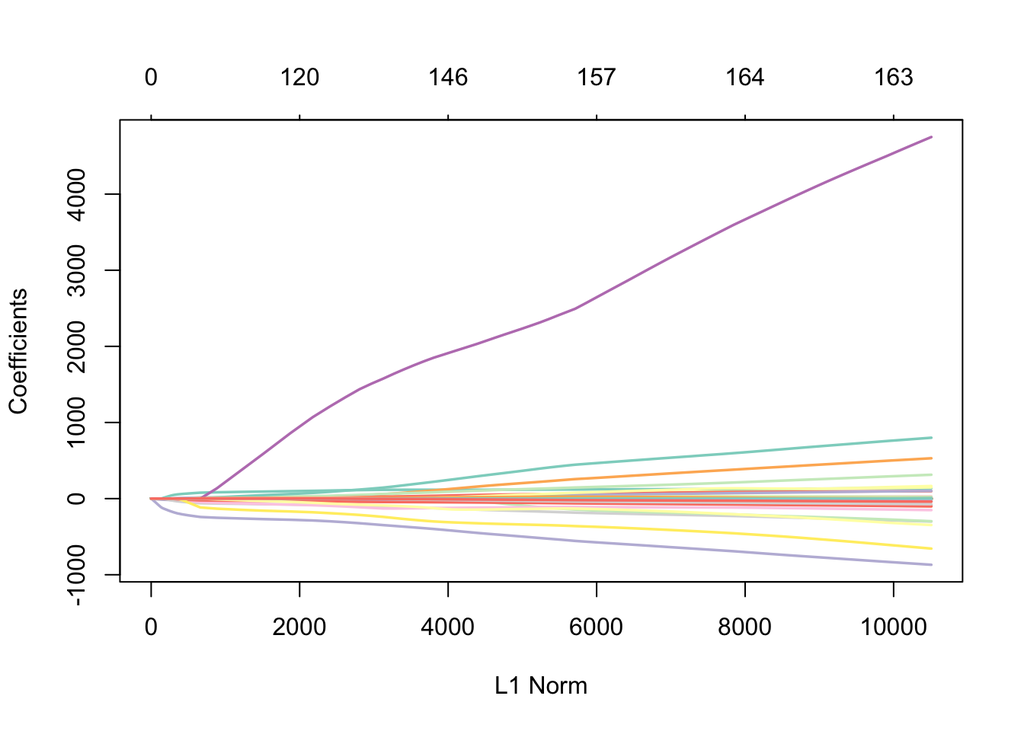

```r
plot(glmfit, xvar = "norm", col = RColorBrewer::brewer.pal(12, "Set3"), lwd = sqrt(3))
```

What is the x-axis? What are the different lines? Check the `plot.glmnet` documentation.

In particular, we note that as the penalty $\lambda$ increases, the L1 Norm of the coefficients ($\sum |\beta_i|$) shrinks.

For example as above let’s see what fitted coefficients we got for $\lambda = 0.04$:

```r
fitted_beta = coef(glmfit, s=0.04)
sum(abs(fitted_beta))
```

```
## [1] 1205.011
```

Let’s try with larger $\lambda$:

```r
sum(abs(coef(glmfit, s=0.1)))
```

```
## [1] 40.61502
```

**Quiz question 3**: Inspect the `glmfit` object: For how many different values of $\lambda$ did `glmnet` fit the model using settings as above?

**Quiz question 4**: For each of the values of $\lambda$ in the object above, calculate the L1 Norm (as we did above for two values of $\lambda$). Which $\lambda$ most closely corresponds to a L1 norm 6000?

**Quiz question 5**: How many non-zero coefficients do you get for the $\lambda$ that you found in the previous question?

To choose the best regularization parameter $\lambda$, we use cross-validation.

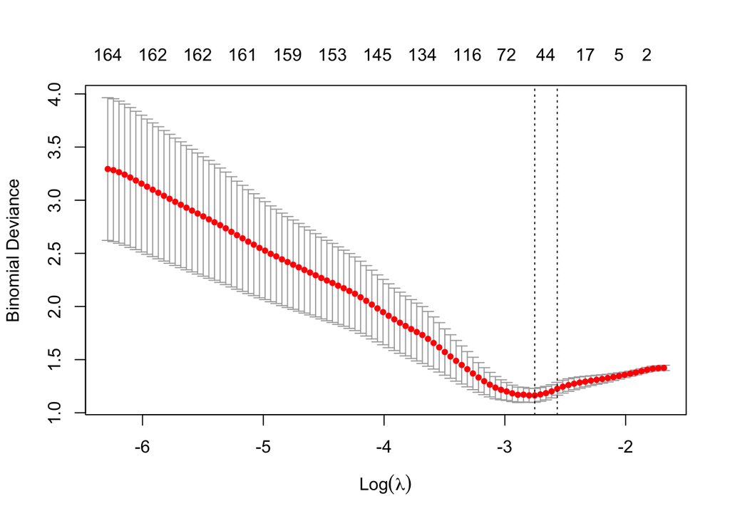

```r
set.seed(0xdada2)
cvglmfit = cv.glmnet(x = t(exprs(zellerNC)),
                     y = factor(zellerNC$disease),
                     family = "binomial")
plot(cvglmfit)
```

We can access the optimal value with:

```r
cvglmfit$lambda.min
```

```
## [1] 0.06376534
```

As this value results from finding a minimum in an estimated curve, it turns out that it is often too small, i.,e., that the implied penalization is too weak. A heuristic recommended by the authors of the `glmnet` package is to use a somewhat larger value instead, namely the largest value of $\lambda$ such that the performance measure is within 1 standard error of the minimum.

```r
s0 = cvglmfit$lambda.1se
s0
```

```
## [1] 0.07680558
```

**Quiz question 6**: How does the confusion table look like for $\lambda=$ lambda.1se ? Report the top left element of the confusion table (i.e. number of correctly classified cancer samples). Hint: Use function `predict`.

**Quiz question 7**: What features drive the classification (at the $\lambda$ chosen by cross-validation)? Report the top one. Hint: The first line in the code below might be useful to get you started.

```r
coefs = coef(glmfit)[, which.min(abs(glmfit$lambda - s0))]
```

# Method hacking

We encountered p-value hacking. A similar phenomenon exists in statistical learning: given a dataset, we explore various different methods of preprocessing (such as normalization, outlier detection, transformation, feature selection), try out different machine learning algorithms and tune their parameters until we are content with the result. The measured accuracy is likely to be too optimistic, i.e., will not generalize to a new dataset. Embedding as many of our methodical choices into a computational formalism and having an outer cross-validation loop (not to be confused with the inner loop that does the parameter tuning) will ameliorate the problem. But is unlikely to address it completely, since not all our choices can be formalized.

The gold standard remains validation on truly unseen data. In addition, it is never a bad thing if the classifier is not a black box but can be interpreted in terms of do- main knowledge. Finally, report not just summary statistics, such as misclassification rates, but lay open the complete computational workflow, so that anyone (including your future self) can convince themselves of the robustness of the result or of the influence of the preprocessing, model selection and tuning choices.